# Exercício 1 - Estatistica Básica e Introdução ao R

Leticia Trein

2024-05-25

## Análise de dados saúde

Para a análise dos dados de saúde, foi utilizado o dataset disponibilizado em aula. O dataset contém informações sobre a qualidade do sono, nível de stress, IMC, distúrbio do sono. entre outros.

## Carregando Dados

```r
dados = read.csv('C:/Users/chii/Documents/POS_ESPECIALIZACAO/Estatistica/EXERCICIO 1/dados_exercicio.csv')
```

## Estrutura dos Dados

Para compreender a estrutura dos dados, será usada a função summary

A partir dela, obtivemos as seguintes informações:

```r
summary(dados)
```

```
##    Person.ID         Gender               Age         Occupation
##  Min.   :  1.00   Length:374         Min.   :27.00   Length:374
##  1st Qu.: 94.25   Class :character   1st Qu.:35.25   Class :character
##  Median :187.50   Mode  :character   Median :43.00   Mode  :character
##  Mean   :187.50                      Mean   :42.18
##  3rd Qu.:280.75                      3rd Qu.:50.00
##  Max.   :374.00                      Max.   :59.00
##  Sleep.Duration  Quality.of.Sleep Physical.Activity.Level  Stress.Level
##  Min.   :5.800   Min.   :4.000    Min.   :30.00           Min.   :3.000
##  1st Qu.:6.400   1st Qu.:6.000    1st Qu.:45.00           1st Qu.:4.000
##  Median :7.200   Median :7.000    Median :60.00           Median :5.000
##  Mean   :7.132   Mean   :7.313    Mean   :59.17           Mean   :5.385
##  3rd Qu.:7.800   3rd Qu.:8.000    3rd Qu.:75.00           3rd Qu.:7.000
##  Max.   :8.500   Max.   :9.000    Max.   :90.00           Max.   :8.000
##  BMI.Category       Blood.Pressure       Heart.Rate     Daily.Steps
##  Length:374         Length:374         Min.   :65.00   Min.   : 3000
##  Class :character   Class :character   1st Qu.:68.00   1st Qu.: 5600
##  Mode  :character   Mode  :character   Median :70.00   Median : 7000
##                                        Mean   :70.17   Mean   : 6817
##                                        3rd Qu.:72.00   3rd Qu.: 8000
##                                        Max.   :86.00   Max.   :10000
##  Sleep.Disorder
##  Length:374
##  Class :character
##  Mode  :character
##
##
##
```

### Informações gerais sobre os dados

#### Geral:

1. O dataset possui 374 observações e 13 variáveis
2. Temos variáveis qualitativas (Gênero, Ocupação, Qualidade de sono, Nivel de Estresse, Categoria de IMC e Desordem de sono) e quantitativas (Nivel de atividade física, Batimento Cardíaco, Idade, Passos diários, Pressão Sanguínea e Duração de sono).

#### Gênero

1. Possuímos as variáveis de gênero: Feminino e Masculino.

#### Ocupação

1. Temos como variáveis de ocupação: Contator, Médico, Engenheiro, Advogado, Gerente, Enfermeiro, Representante de Vendas, Vendedor, Cientísta, Engenheiro de software e Professor.

#### Duração de Sono

1. A duração média do sono é de 7,132 horas, a mediana é de 7,2 horas, a duração mínima é de 5,8 horas e a máxima é de 8,5 horas.

#### Qualidade de Sono

1. A qualidade do sono varia de 1 a 10, sendo 1 a pior qualidade e 10 a melhor qualidade. A média é de 7,313 e a mediana é de 7, o valor mínimo atribuido foi 4 e o máximo 9.

#### Nível de Atividade Física

1. O nível de atividade física foi medido por minutos de atividade diário, apresentando o mínimo de 30 min e o máximo de 90 min. A média é de 59,17 min e a mediana de 60 min.

#### Categoria de IMC

1. A categoria de IMC foi dividida em Normal, Sobrepeso e Obeso.
2. Nesta categoria é necessário posterior adequação pois algumas pessoas foram classificadas como ” Peso normal” ao invés de “Normal”.

#### Desordem de Sono

1. As categorias de desordem de sono foram: Insônia, Apneia ou Nenhuma

#### Batimento Cardíaco

1. A variável batimento cardíaco é medida em batimentos por minuto e apresenta uma média de 70,17 batimentos por minuto e uma mediana de 70 batimentos por minuto. O valor mínimo é 65 e o máximo é 86.

#### Passos Diários

1. A variável passos diários é medida em passos por dia e apresenta uma média de 6817 passos por dia e uma mediana de 7000 passos por dia. O valor mínimo é 3000 e o máximo é 10000.

## Análise individual das variáveis

Nesta sessão iremos avaliar individualmente algumas variáveis de interesse, mostrando variações de como podem ser compriendidas tipos diferentes de variáveis.

## Idade

```r
summary(dados$Age)
```

```
##    Min. 1st Qu.  Median    Mean 3rd Qu.    Max.
##   27.00   35.25   43.00   42.18   50.00   59.00
```

### Obtivemos como resultado da análise:

#### Apresentação Gráfica:

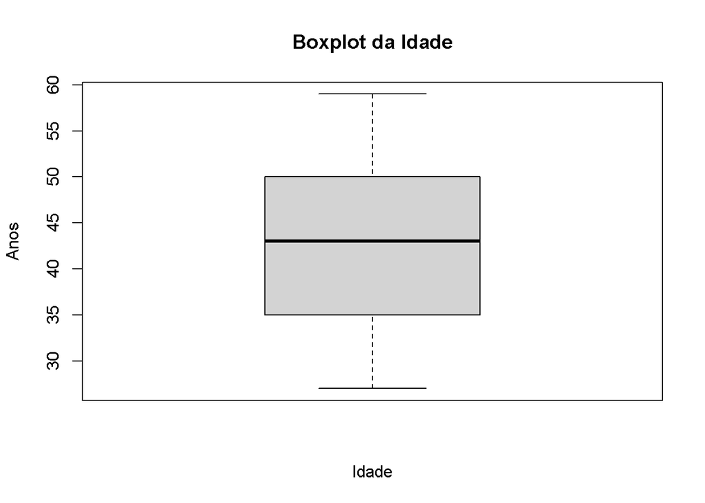

```r
boxplot(dados$Age, main = "Boxplot da Idade", xlab = "Idade", ylab = "Anos")
```

## Gênero

```r
table(dados$Gender) ## mostra a frequencia absoluta de cada variável
```

```
##
## Female   Male
##    185    189
```

```r
round(prop.table(table(dados$Gender))*100, 1) # mostra percentual dos sexos
```

```
##
## Female   Male
##   49.5   50.5
```

### Obtivemos como resultado da análise:

Frequência absoluta de homens: 189 e de mulheres: 185 Frequência relativa de homens: 50,5% e de mulheres: 49,5%

#### Apresentação Gráfica:

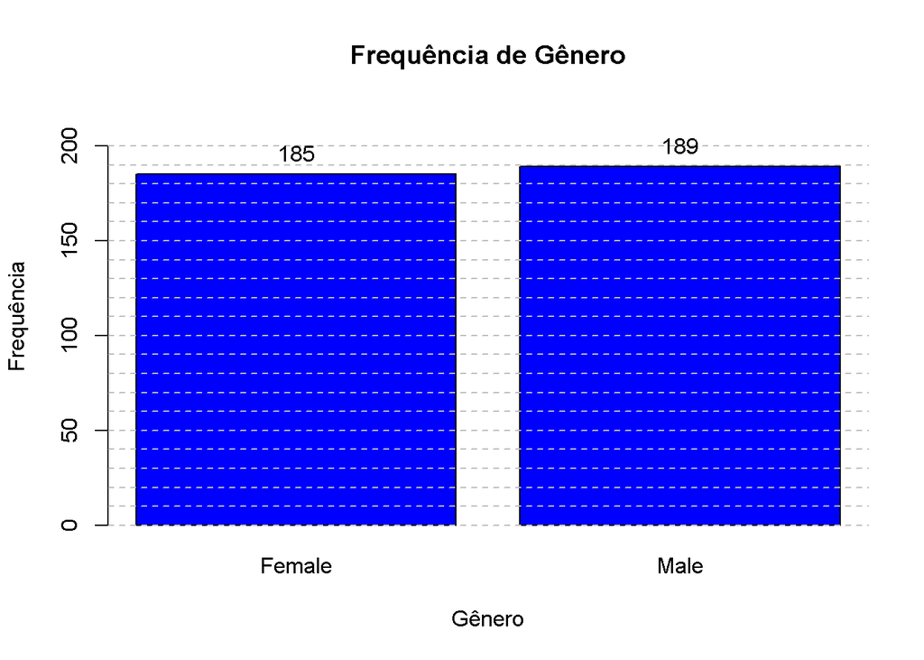

```r
bar_plot <- barplot(table(dados$Gender), main = "Frequência de Gênero", col = "blue", xlab = "Gênero", ylab = "Frequência", ylim = c(0, 220))
abline(h = seq(0, 200, by = 10), col = "gray", lty = "dashed")
text(bar_plot, table(dados$Gender), labels = table(dados$Gender), pos = 3)
```

## Ocupação

```r
frequencia_absoluta <- table(dados$Occupation)
frequencia_relativa <- prop.table(frequencia_absoluta) * 100
```

#### Criando dataframe para melhor visualização:

```r
df <- data.frame(
  Occupation = names(frequencia_absoluta),
  Frequencia_Absoluta = as.numeric(frequencia_absoluta),
  Frequencia_Relativa = as.numeric(frequencia_relativa)
)
df <- df[order(-df$Frequencia_Relativa), ]
head(df)
```

```
##    Occupation Frequencia_Absoluta Frequencia_Relativa
## 6       Nurse                  73           19.518717
## 2      Doctor                  71           18.983957
## 3    Engineer                  63           16.844920
## 4      Lawyer                  47           12.566845
## 11    Teacher                  40           10.695187
## 1  Accountant                  37            9.893048
```

### Obtivemos como resultado da análise:

As 6 profissões mais frequentes são: Enfermeiro (73 - 19,5%), Médico (71 - 19%), Engenheiro(63 - 16,8%), Advogado(47 - 12,6%), Professor(40 - 10,7%) e Contador(37 - 9,9%).

#### Apresentação Gráfica:

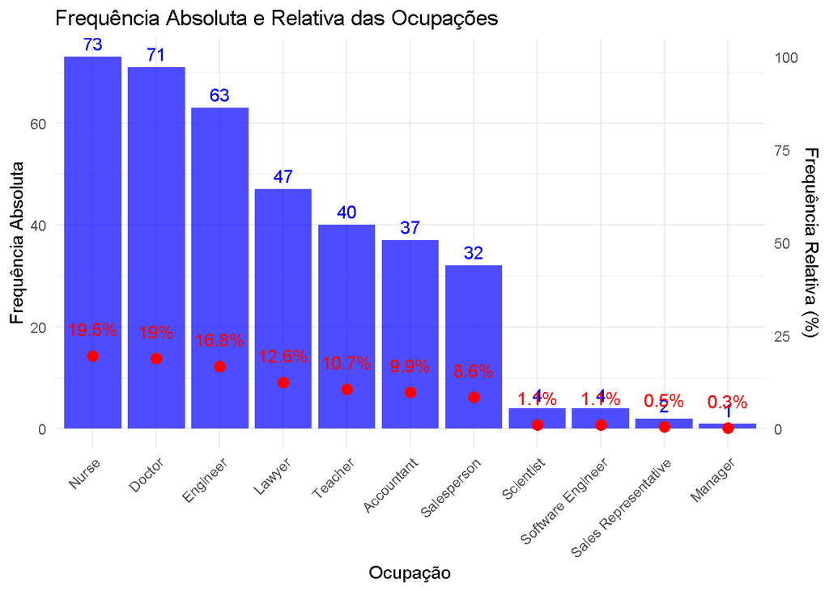

```r
library(ggplot2)
ggplot2::ggplot(df, aes(x = reorder(Occupation, -Frequencia_Absoluta))) +
  geom_bar(aes(y = Frequencia_Absoluta), stat = "identity", fill = "blue", alpha = 0.7) +
  geom_text(aes(y = Frequencia_Absoluta, label = Frequencia_Absoluta), vjust = -0.5, color = "blue") +
  geom_point(aes(y = Frequencia_Relativa * max(Frequencia_Absoluta) / 100), color = "red", size = 3) +
  geom_text(aes(y = Frequencia_Relativa * max(Frequencia_Absoluta) / 100, label = paste0(round(Frequencia_Relativa, 1), "%")), vjust = -1.5, color = "red") +
  scale_y_continuous(sec.axis = sec_axis(~ . * 100 / max(df$Frequencia_Absoluta), name = "Frequência Relativa (%)")) +
  labs(title = "Frequência Absoluta e Relativa das Ocupações",
       x = "Ocupação",
       y = "Frequência Absoluta",
       fill = "Legenda") +
  theme_minimal() +
  theme(axis.text.x = element_text(angle = 45, hjust = 1))
```

## Duração de Sono

```r
summary(dados$Sleep.Duration)
```

```
##    Min. 1st Qu.  Median    Mean 3rd Qu.    Max.
##   5.800   6.400   7.200   7.132   7.800   8.500
```

### Obtivemos como resultado da análise:

A duração mínima foi de 5,8h de sono, o primeiro quartil com 6,4h, a média de 7,132h, a mediana de 7,2h, o terceiro quartil com 7,8h e a duração máxima de 8,5h.

#### Apresentação Gráfica:

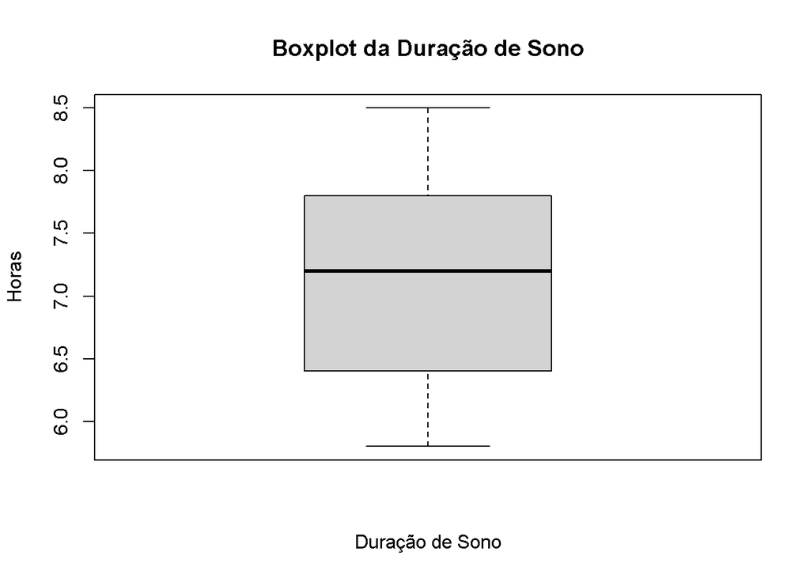

```r
boxplot(dados$Sleep.Duration, main = "Boxplot da Duração de Sono", xlab = "Duração de Sono", ylab = "Horas")
```

## Qualidade de Sono

```r
summary(dados$Quality.of.Sleep)
```

```
##    Min. 1st Qu.  Median    Mean 3rd Qu.    Max.
##   4.000   6.000   7.000   7.313   8.000   9.000
```

```r
qualidade_sono <- round(prop.table(table(dados$Quality.of.Sleep))*100, 1)
qualidade_sono
```

```
##
##    4    5    6    7    8    9
##  1.3  1.9 28.1 20.6 29.1 19.0
```

```r
qualidade_alta <- sum(qualidade_sono[c("8", "9")])
qualidade_media <- sum(qualidade_sono[c("6", "7")])
qualidade_baixa <- sum(qualidade_sono[c("4", "5")])
```

### Obtivemos como resultado da análise:

1.Considerando como variável qualitativa onde o valor 1 corresponde à menor qualidade de sono e valor 10 a maior qualidade

2.A menor nota dada foi 4, o primeiro quartil apresentou nota 6, a média foi 7,313, a mediana 7, o terceiro quartil 8 e a maior nota 9

3. Se avaliar de forma categórica, entre Baixa qualidade de sono (notas até 5), Média qualidade (entre 6 e 7) e Alta qualidade (notas 8 e 10), temos que 48,1% dos participantes apresentam alta qualidade de sono, 48,7% média qualidade e 3,2% baixa qualidade.

#### Apresentação Gráfica:

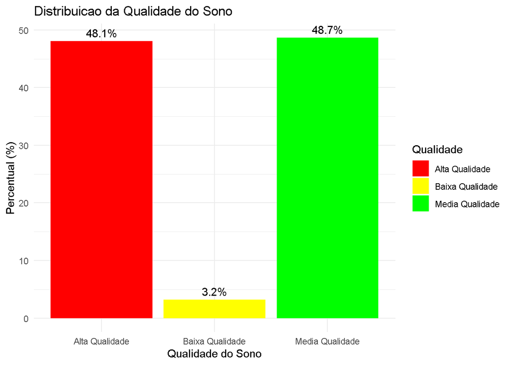

```r
# Criar um dataframe
df_qualidade <- data.frame(
  Qualidade = c("Baixa Qualidade", "Media Qualidade", "Alta Qualidade"),
  Percentual = c(qualidade_baixa, qualidade_media, qualidade_alta)
)
# Criar o gráfico de barras
ggplot(df_qualidade, aes(x = Qualidade, y = Percentual, fill = Qualidade)) +
  geom_bar(stat = "identity") +
  geom_text(aes(label = paste0(Percentual, "%")), vjust = -0.5) +
  labs(title = "Distribuicao da Qualidade do Sono",
       x = "Qualidade do Sono",
       y = "Percentual (%)") +
  scale_fill_manual(values = c("red", "yellow", "green")) +
  theme_minimal()
```

## Nível de Atividade Física

```r
summary(dados$Physical.Activity.Level)
```

```
##    Min. 1st Qu.  Median    Mean 3rd Qu.    Max.
##   30.00   45.00   60.00   59.17   75.00   90.00
```

```r
frequencias_absolutas <- table(dados$Physical.Activity.Level)
frequencias_absolutas
```

```
##
## 30 32 35 40 42 45 47 50 55 60 65 70 75 80 85 90
## 68  2  4  6  2 68  1  4  6 70  2  3 67  2  2 67
```

### Obtivemos como resultado da análise:

1. A menor quantidade de minutos de atividade física foi 30 min, o primeiro quartil apresentou 45 min, a média foi 59,17 min, a mediana 60 min, o terceiro quartil 75 min e a maior quantidade de minutos 90 min.
2. Ao analisar a frequência absoluta de minutos de atividade física, temos que 60min foi a quantidade de minutos mais frequente, com 70 participantes, seguido de 30 e 45 min com 68 participantes e 75 e 90 min com 67 participantes.

#### Apresentação Gráfica:

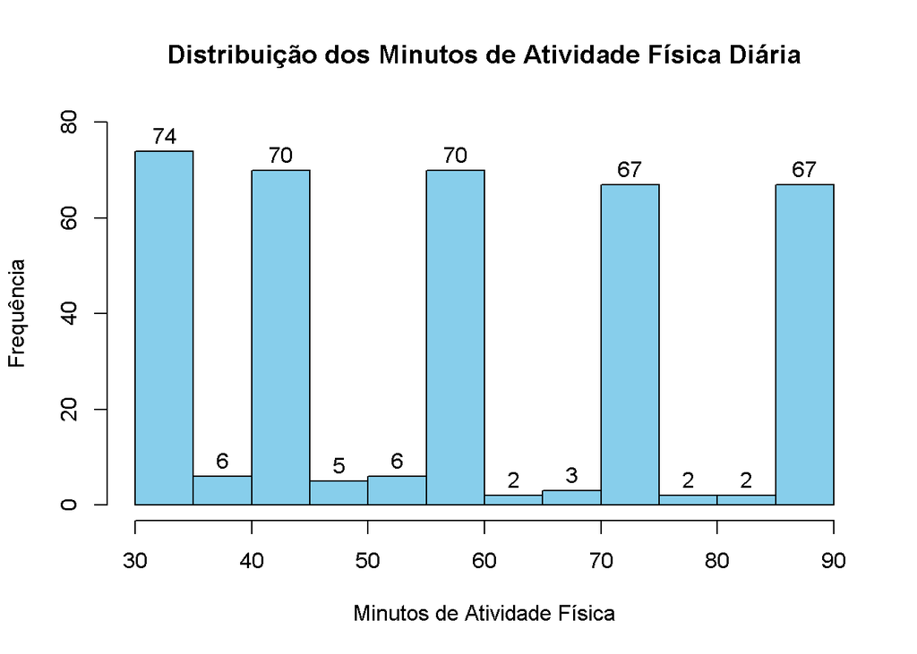

```r
hist(dados$Physical.Activity.Level,
     main = "Distribuição dos Minutos de Atividade Física Diária",
     xlab = "Minutos de Atividade Física",
     ylab = "Frequência",
     col = "skyblue",
     border = "black",
     ylim = c(0, 80), # Definindo os limites do eixo y
     axes = TRUE, # Exibir eixos
     labels = TRUE, # Exibir labels
     )
```

## Nível de Estresse

```r
summary(dados$Stress.Level)
```

```
##    Min. 1st Qu.  Median    Mean 3rd Qu.    Max.
##   3.000   4.000   5.000   5.385   7.000   8.000
```

```r
frequencias_absolutas <- table(dados$Stress.Level)
frequencias_absolutas
```

```
##
##  3  4  5  6  7  8
## 71 70 67 46 50 70
```

#### Apresentação Gráfica:

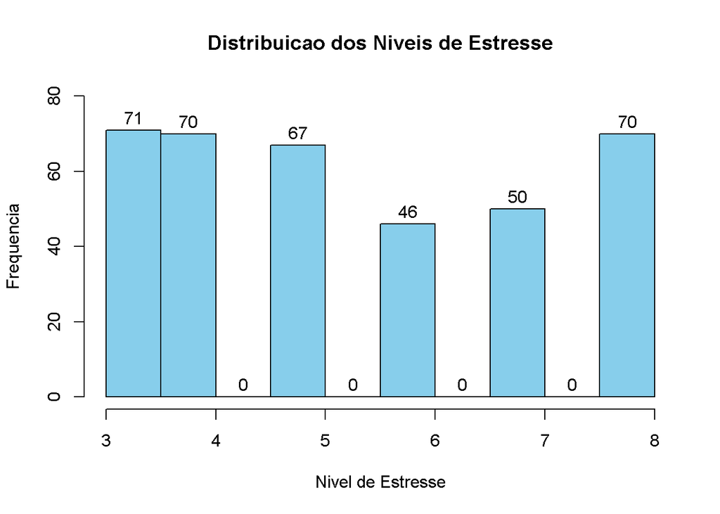

```r
niveis_estresse <- dados$Stress.Level
# Criar histograma
hist(niveis_estresse,
     main = "Distribuicao dos Niveis de Estresse",
     xlab = "Nivel de Estresse",
     ylab = "Frequencia",
     col = "skyblue",
     border = "black",
     xlim = c(3, 8), # Definindo os limites do eixo x
     ylim = c(0, 80), # Definindo os limites do eixo y
     axes = TRUE, # Exibir eixos
     labels = TRUE, # Exibir labels
     )
```

## Análises combinadas

Considerando agora as variáveis qualitativas e quantitativas, iremos avaliar a relação entre elas.

## Avaliação de Estresse

O estresse é um conhecido fator de risco para doenças psicossomáticas, com alterações de níveis sorológicos de corticoides e demais neurotransmissores relacionados ao estresse podem levar a alterações cardiovasculares. Ainda, o estresse pode ter relação com a atividade ocupacional, níveis de sono e atividade física, devido a isso iremos avaliar as relações entre o nível de estresse e a ocupação, qualidade de sono e nível de atividade física.

### Nível de Estresse por Gênero

```r
stress_genero <- table(dados$Gender, dados$Stress.Level)
porcentagem_stress_genero <- prop.table(stress_genero, margin = 1) * 100
porcentagem_stress_genero
```

```
##
##                  3         4         5         6         7         8
##   Female 36.216216 32.972973  1.081081  4.864865  6.486486 18.378378
##   Male    2.116402  4.761905 34.391534 19.576720 20.105820 19.047619
```

#### Apresentação Gráfica:

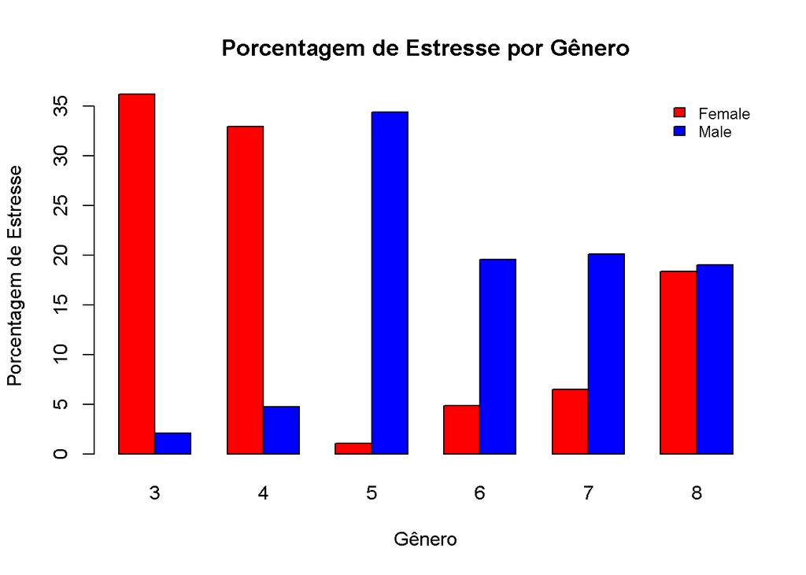

```r
barplot(porcentagem_stress_genero,
        beside = TRUE,
        main = "Porcentagem de Estresse por Gênero",
        xlab = "Gênero",
        ylab = "Porcentagem de Estresse",
        col = c("red", "blue"), # Cores das barras para cada gênero
        legend.text = TRUE,
        args.legend = list(x = "topright", bty = "n", cex = 0.8))
```

### Nível de Estresse por Ocupação

```r
stress_ocupacao <- table(dados$Occupation, dados$Stress.Level)
porcentagem_stress_ocupacao <- round(prop.table(stress_ocupacao, margin=1)*100,1)
porcentagem_stress_ocupacao
```

```
##
##                            3     4     5     6     7     8
##   Accountant             5.4  70.3   0.0   8.1  16.2   0.0
##   Doctor                 5.6   0.0   2.8  45.1   0.0  46.5
##   Engineer              54.0  14.3  25.4   1.6   4.8   0.0
##   Lawyer                 0.0   0.0  93.6   6.4   0.0   0.0
##   Manager                0.0   0.0 100.0   0.0   0.0   0.0
##   Nurse                 42.5   5.5   0.0   2.7   5.5  43.8
##   Sales Representative   0.0   0.0   0.0   0.0   0.0 100.0
##   Salesperson            0.0   0.0   0.0   0.0 100.0   0.0
##   Scientist              0.0   0.0   0.0  50.0   0.0  50.0
##   Software Engineer      0.0   0.0  50.0  25.0   0.0  25.0
##   Teacher                0.0  77.5   5.0   5.0  12.5   0.0
```

#### Apresentação Gráfica:

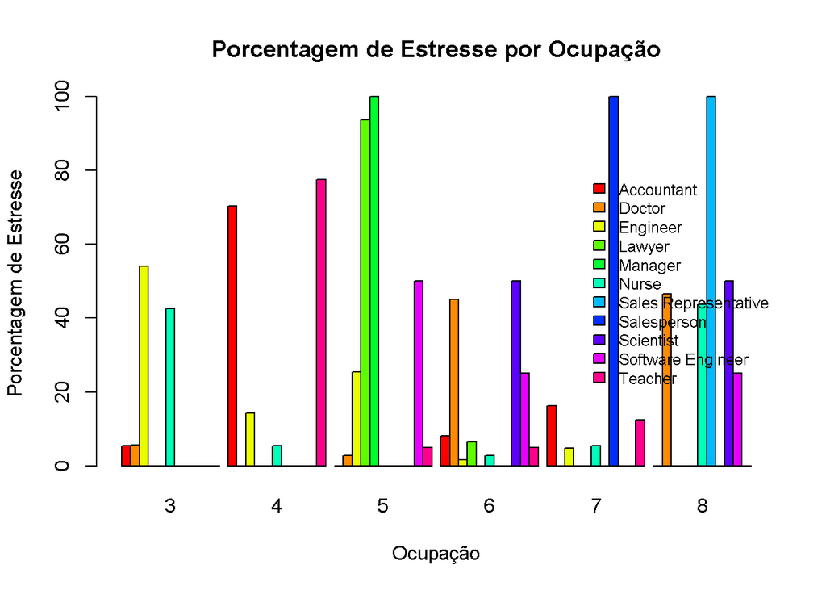

```r
barplot(porcentagem_stress_ocupacao,
        beside = TRUE,
        main = "Porcentagem de Estresse por Ocupação",
        xlab = "Ocupação",
        ylab = "Porcentagem de Estresse",
        col = rainbow(nrow(porcentagem_stress_ocupacao)),
        legend.text = TRUE,
        args.legend = list(x = "right", y = 0.5, bty = "n", cex = 0.8))
```

#### Obtivemos como resultado da análise:

1.Observamos ao análisar a porcentagem de amostras por ocupação que o 46,5% dos médicos avaliaram seu estresse em 8, assim como 43,8% das enfermeiras. É de destaque que 100% dos representantes de vendas também apresentaram nível 8 de estresse, e todos os vendedores apresentaram nível 7 de estresse.

2. Acerca das ocupações de menor nível de estresse, vemos um destaque para os engenheiros, que mais da metade (54%) definiram seu nível de estresse como 3, os contatores também apresentaram de forma geral menor nível de estresse, com 75,7% apesentam nível menor ou igual a 44 e 77,5 % dos professores definiram seu estresse como nível 4.

## Avaliação de correlações das variáveis quantitativas

```r
dados_numericos <- dados[, sapply(dados, is.numeric)]
correlacoes <- cor(dados_numericos[, -which(names(dados_numericos) == "Stress.Level")], dados_numericos$Stress.Level, method = "spearman")
print(correlacoes)
```

```
##                                [,1]
## Person.ID               -0.42472493
## Age                     -0.42562182
## Sleep.Duration          -0.81063256
## Quality.of.Sleep        -0.90814704
## Physical.Activity.Level -0.01749743
## Heart.Rate               0.82029661
## Daily.Steps              0.17174384
```

## Apresentação Gráfica:

### Qualidade de Sono e Nível de Estresse

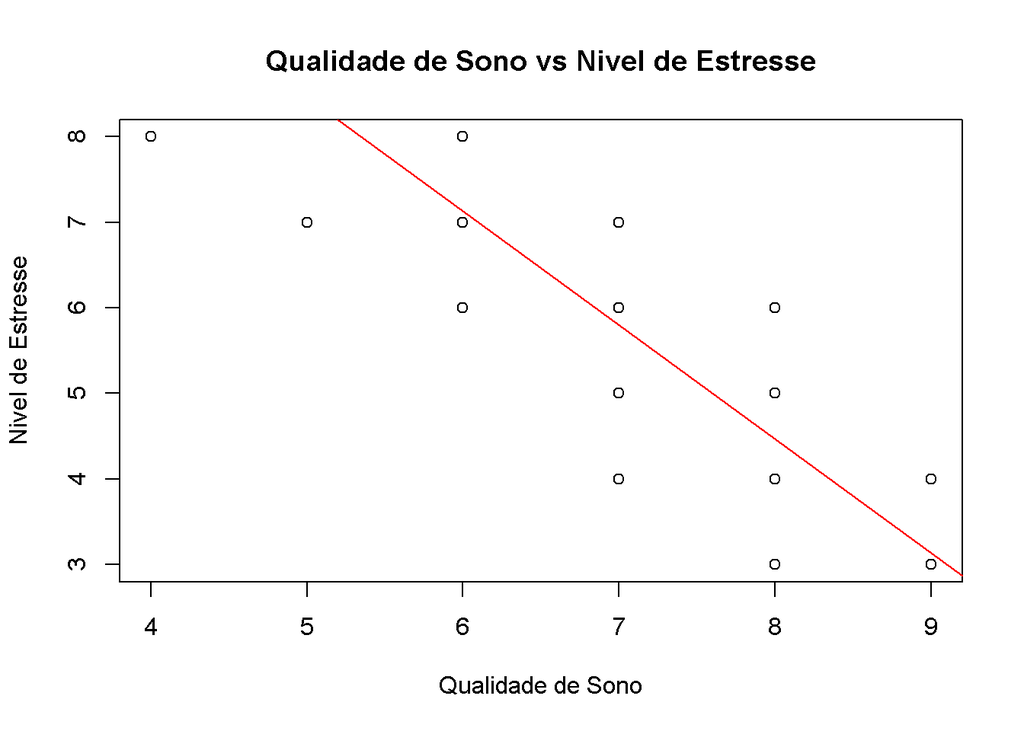

```r
plot(dados$Quality.of.Sleep, dados$Stress.Level,
     main = "Qualidade de Sono vs Nivel de Estresse",
     xlab = "Qualidade de Sono",
     ylab = "Nivel de Estresse")
tendencia <- lm(dados$Stress.Level ~ dados$Quality.of.Sleep)
abline(tendencia, col = "red")
```

### Duração de sono e Nível de Estresse

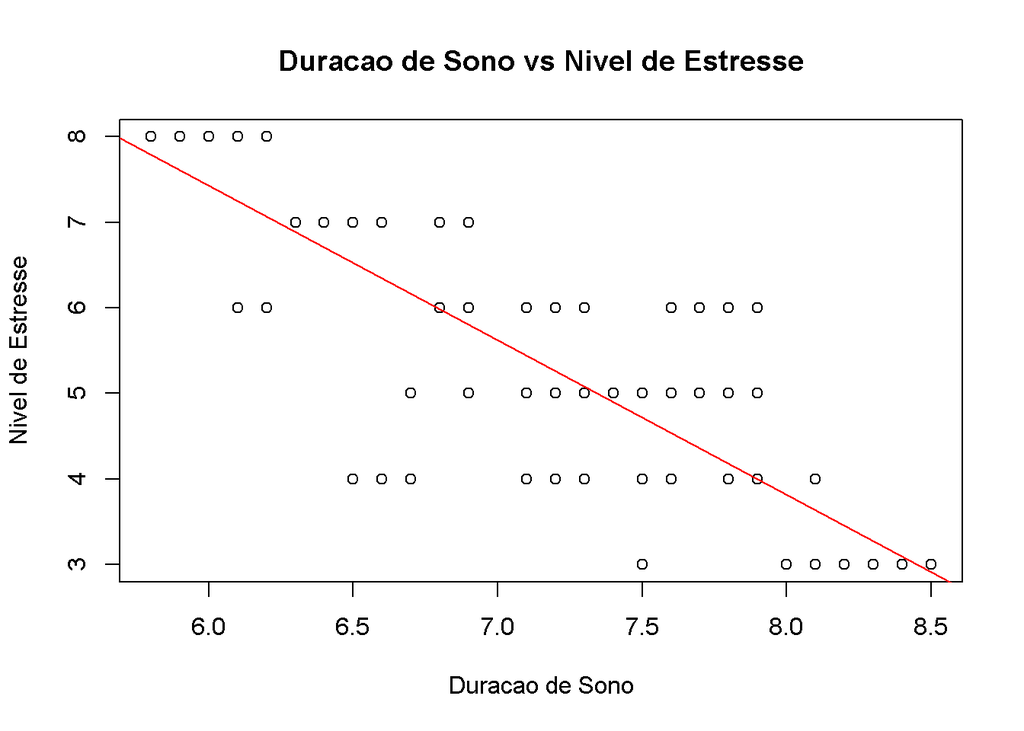

```r
plot(dados$Sleep.Duration, dados$Stress.Level,
     main = "Duracao de Sono vs Nivel de Estresse",
     xlab = "Duracao de Sono",
     ylab = "Nivel de Estresse")
tendencia <- lm(dados$Stress.Level ~ dados$Sleep.Duration)
abline(tendencia, col = "red")
```

### Batimento Cardiaco e Nível de Estresse

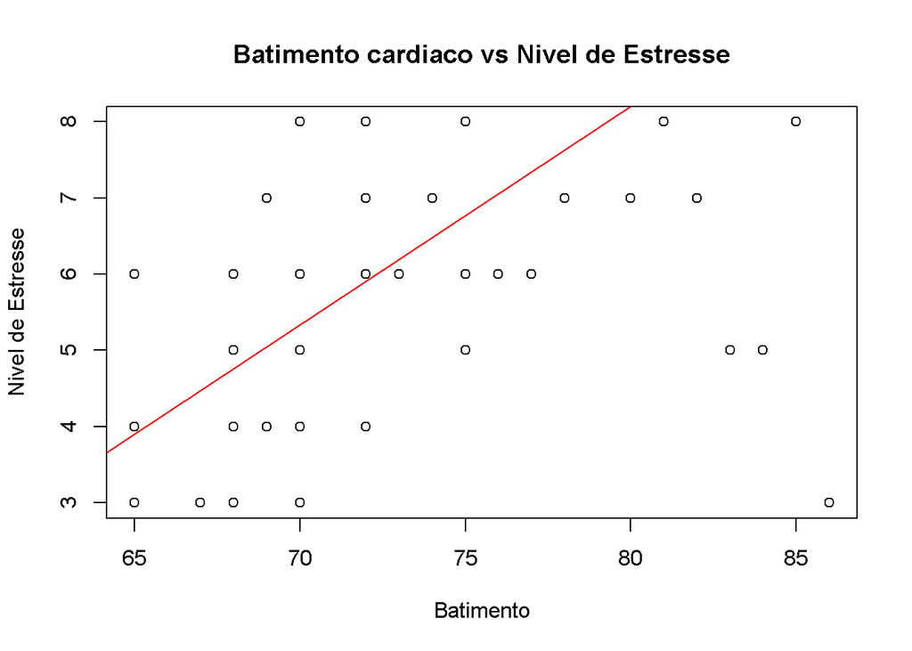

```r
plot(dados$Heart.Rate, dados$Stress.Level,
     main = "Batimento cardiaco vs Nivel de Estresse",
     xlab = "Batimento",
     ylab = "Nivel de Estresse")
tendencia <- lm(dados$Stress.Level ~ dados$Heart.Rate)
abline(tendencia, col = "red")
```

### Nível de Atividade Física e Nível de Estresse

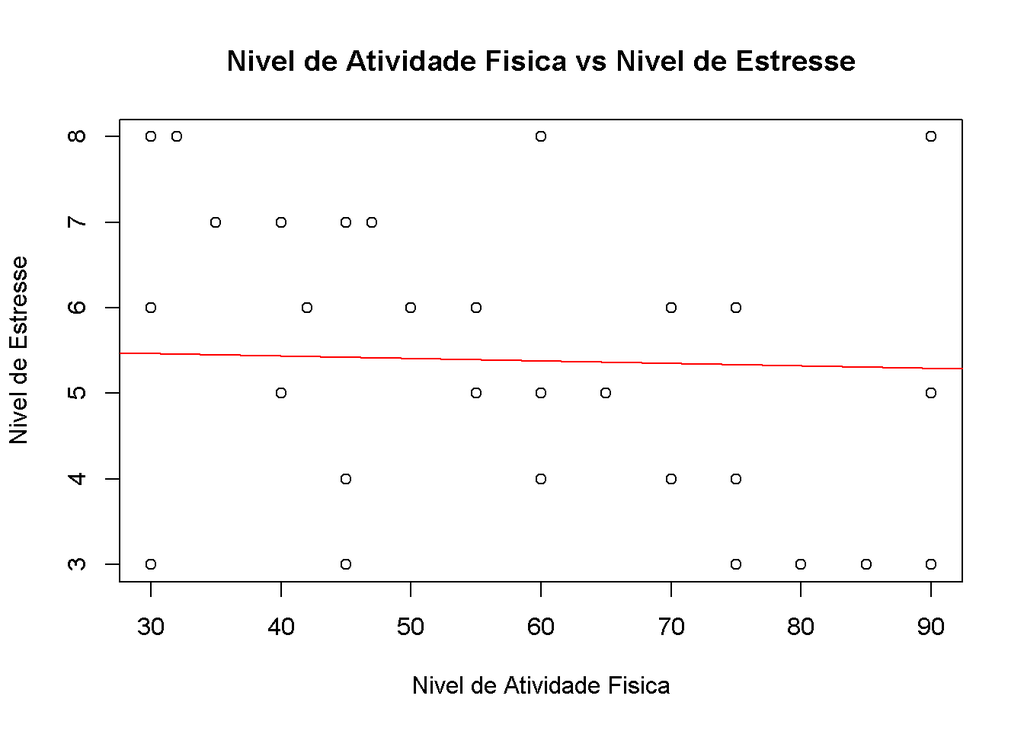

```r
plot(dados$Physical.Activity.Level, dados$Stress.Level,
     main = "Nivel de Atividade Fisica vs Nivel de Estresse",
     xlab = "Nivel de Atividade Fisica",
     ylab = "Nivel de Estresse")
tendencia <- lm(dados$Stress.Level ~ dados$Physical.Activity.Level)
abline(tendencia, col = "red")
```

### Número de passos e Nível de Estresse

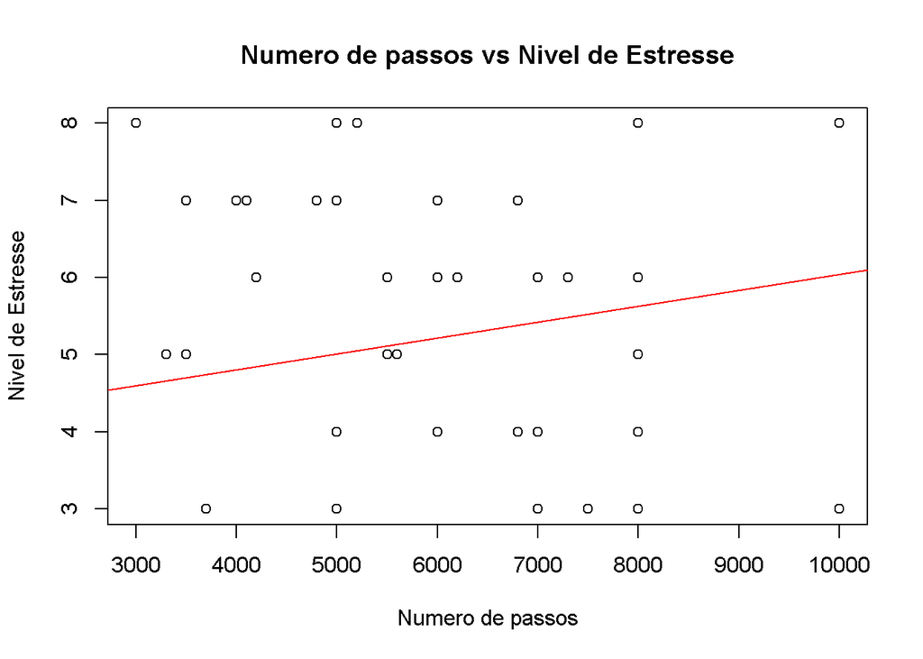

```r
plot(dados$Daily.Steps, dados$Stress.Level,
     main = "Numero de passos vs Nivel de Estresse",
     xlab = "Numero de passos",
     ylab = "Nivel de Estresse")
tendencia <- lm(dados$Stress.Level ~ dados$Daily.Steps)
abline(tendencia, col = "red")
```